# R Notebook

# I) Cleaning the Data

## A) Reading and understand our dataset

Read data directly from our website

```r
#data=read.csv("movies/movie_metadata.csv", na.strings = c("NA", ""))
data <- read.csv(url('http://suberalex.com/movie_metadata.csv'), na.strings = c("NA", ""))
data =  data %>% distinct() #removing duplicates
```

```r
dim(data)
```

```
## [1] 4998   28
```

Our dataset has 4998 rows and 28 columns. Let’s inspect it.

```r
summary(data)
```

```
##               color               director_name  num_critic_for_reviews
##   Black and White: 207   Steven Spielberg:  26   Min.   :  1.0
##  Color           :4772   Woody Allen     :  22   1st Qu.: 50.0
##  NA's            :  19   Clint Eastwood  :  20   Median :110.0
##                          Martin Scorsese :  20   Mean   :139.9
##                          Ridley Scott    :  17   3rd Qu.:195.0
##                          (Other)         :4790   Max.   :813.0
##                          NA's            : 103   NA's   :49
##     duration     director_facebook_likes actor_3_facebook_likes
##  Min.   :  7.0   Min.   :    0.0         Min.   :    0.0
##  1st Qu.: 93.0   1st Qu.:    7.0         1st Qu.:  133.0
##  Median :103.0   Median :   49.0         Median :  369.0
##  Mean   :107.2   Mean   :  688.7         Mean   :  639.9
##  3rd Qu.:118.0   3rd Qu.:  192.0         3rd Qu.:  635.0
##  Max.   :511.0   Max.   :23000.0         Max.   :23000.0
##  NA's   :15      NA's   :103             NA's   :23
##           actor_2_name  actor_1_facebook_likes     gross
##  Morgan Freeman :  20   Min.   :     0.0       Min.   :      162
##  Charlize Theron:  15   1st Qu.:   611.5       1st Qu.:  5304835
##  Brad Pitt      :  13   Median :   984.0       Median : 25445749
##  James Franco   :  11   Mean   :  6556.9       Mean   : 48325649
##  Meryl Streep   :  11   3rd Qu.: 11000.0       3rd Qu.: 62319416
##  (Other)        :4915   Max.   :640000.0       Max.   :760505847
##  NA's           :  13   NA's   :7              NA's   :874
##                   genres             actor_1_name
##  Drama               : 235   Robert De Niro:  49
##  Comedy              : 205   Johnny Depp   :  40
##  Comedy|Drama        : 189   Nicolas Cage  :  32
##  Comedy|Drama|Romance: 187   J.K. Simmons  :  31
##  Comedy|Romance      : 158   Bruce Willis  :  30
##  Drama|Romance       : 151   (Other)       :4809
##  (Other)             :3873   NA's          :   7
##                          movie_title   num_voted_users
##  Ben-HurÂ                      :   3   Min.   :      5
##  HomeÂ                         :   3   1st Qu.:   8560
##  King KongÂ                    :   3   Median :  34261
##  20,000 Leagues Under the SeaÂ :   2   Mean   :  83470
##  A Nightmare on Elm StreetÂ    :   2   3rd Qu.:  96121
##  Across the UniverseÂ          :   2   Max.   :1689764
##  (Other)                       :4983
```

[output cut: 33 more lines]

```
##  Min.   :2.180e+02   Min.   :1916   Min.   :     0         Min.   :1.600
##  1st Qu.:6.000e+06   1st Qu.:1999   1st Qu.:   280         1st Qu.:5.800
##  Median :2.000e+07   Median :2005   Median :   595         Median :6.600
##  Mean   :3.975e+07   Mean   :2002   Mean   :  1643         Mean   :6.441
##  3rd Qu.:4.500e+07   3rd Qu.:2011   3rd Qu.:   917         3rd Qu.:7.200
##  Max.   :1.222e+10   Max.   :2016   Max.   :137000         Max.   :9.500
##  NA's   :487         NA's   :107    NA's   :13
##   aspect_ratio    movie_facebook_likes
##  Min.   : 1.180   Min.   :     0.0
##  1st Qu.: 1.850   1st Qu.:     0.0
##  Median : 2.350   Median :   162.5
##  Mean   : 2.221   Mean   :  7487.4
##  3rd Qu.: 2.350   3rd Qu.:  3000.0
##  Max.   :16.000   Max.   :349000.0
##  NA's   :327
```

That is a lot of variables, we might need to delete some that are irrelevant. What about the missing data ?

```r
data %>% summarise_all(funs(mean(is.na(.))))
```

```
##         color director_name num_critic_for_reviews  duration
## 1 0.003801521    0.02060824            0.009803922 0.0030012
##   director_facebook_likes actor_3_facebook_likes actor_2_name
## 1              0.02060824            0.004601841   0.00260104
##   actor_1_facebook_likes     gross genres actor_1_name movie_title
## 1             0.00140056 0.1748699      0   0.00140056           0
##   num_voted_users cast_total_facebook_likes actor_3_name facenumber_in_poster
## 1               0                         0  0.004601841           0.00260104
##   plot_keywords movie_imdb_link num_user_for_reviews   language   country
## 1    0.03041216               0          0.004201681 0.00240096 0.0010004
##   content_rating     budget title_year actor_2_facebook_likes imdb_score
## 1     0.06022409 0.09743898 0.02140856             0.00260104          0
##   aspect_ratio movie_facebook_likes
## 1   0.06542617                    0
```

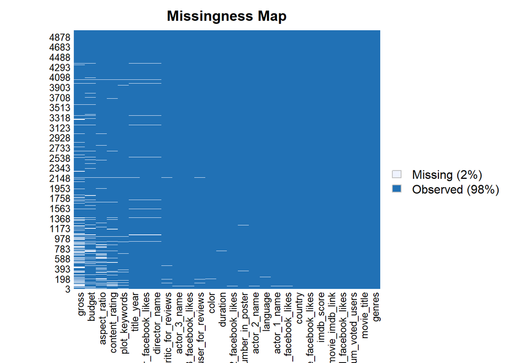

```r
missmap(data)
```

We see that we have a lot of missing data on some variables. How to handle the Facebook likes ?

```r
fb_likes = data %>%  select(contains("likes"))
fb_likes %>% summarise_all(funs(na = mean(is.na(.) | (. == 0), na.rm=T)))
```

```
##   director_facebook_likes_na actor_3_facebook_likes_na
## 1                    0.20008                0.02240896
##   actor_1_facebook_likes_na cast_total_facebook_likes_na
## 1               0.006602641                  0.006602641
##   actor_2_facebook_likes_na movie_facebook_likes_na
## 1                0.01360544                0.432573
```

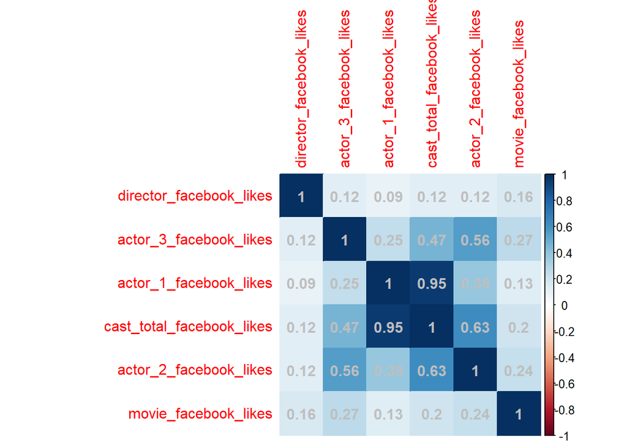

```r
fb_likes = fb_likes %>% drop_na()
data_cor <- cor(fb_likes)
corrplot(corr = data_cor, method = 'color', addCoef.col="grey")
```

We come up with the folliwing guidelines for data cleaning:

## B) Cleaning

GUIDELINES for data cleaning :

**All the movie titles have a special character A in the end, we need to remove them**

“movie_title”

**Keeping only the TOP N values, packing the remaining lot under “Other”**

“director_name” “actor_2_name” “actor_1_name” “actor_3_name” “genres” (*note*: one film can have several genres, we’ll pack all this in a matrix)

**Filering on values:** “country”: keep only USA, UK and France

**Replacing NA and 0 values with average value** “duration” “actor_3_facebook_likes” “actor_2_facebook_likes” “actor_1_facebook_likes”

**USELESS variables to remove:** “num_critic_for_reviews” “plot_keywords” “num_user_for_reviews” “movie_imdb_link” “color” “aspect_ratio” “language” (most are English after filtering for european and US films), “movie_facebook_likes” (almost half unknown) “director_facebook_likes”: too much missing data “cast_total_facebook_likes” (we only the highly correlated keep the 3 actors)

*FULL CLEANING CODE*:

```r
data$movie_title <- gsub("Â", "", as.character(factor(data$movie_title)))

c_ratings = c("Approved"="G", "GP"="PG", "Unrated"="NC-17", "Not Rated"="NC-17", "Passed"="G", "X"="NC-17", "M"="NC-17")
dim(data)
```

```
## [1] 4998   28
```

```r
data_year = data %>% filter(title_year!=2015)
dim(data_year)
```

```
## [1] 4669   28
```

```r
data_country = data_year %>% filter(grepl("(UK|USA|France)", country))
dim(data_country)
```

```
## [1] 4091   28
```

```r
data_cleaned = data_country %>% drop_na("num_voted_users", "facenumber_in_poster", "budget", "imdb_score", "title_year", "gross", "director_name", "actor_1_name")
dim(data_cleaned)
```

```
## [1] 3345   28
```

```r
data_cleaned=data_cleaned %>%
  mutate(content_rating=factor(recode_factor(content_rating, !!!c_ratings))) %>%
  #if NA, we consider it for General Audience
  mutate(content_rating=replace_na(content_rating, "G" )) %>%
  #change factors into characrers, will be easier for further processing %>%
  mutate(actor_1_name=as.character(actor_1_name), actor_2_name=as.character(actor_2_name),
         actor_3_name=as.character(actor_3_name), director_name=as.character(director_name))
```

```r
#Drop useless variables
data_cleaned = data_cleaned %>% select(-c(num_critic_for_reviews, plot_keywords, num_user_for_reviews, movie_imdb_link, color, aspect_ratio, language, movie_facebook_likes, director_facebook_likes, cast_total_facebook_likes))
dim(data_cleaned)
```

```
## [1] 3345   18
```

*Processing names*: replace director names with a variable coding for the average IMDB score of their previous movies. We cannot avoid NA values:  
Yes, every director has at least ONE unkown value corresponding to the first of his film appearing in the database. For one-time director, we will therefore never have any meaningful score. Moreother, some directors did more than one film in their first year, and our method doesn’t give any value to all theses films either. So the total number of unknown values should be: number of distinct directors **+** ((number of films did the first year - 1) by director)

```r
first_y = data_cleaned %>%
  group_by(director_name, title_year) %>%
  summarise(count=n()) %>% ungroup() %>%
  group_by(director_name) %>%
  top_n(-1, title_year) %>% ungroup() %>%
  mutate(count = count -1) %>%
  summarise(count=sum(count))
(first_y + n_distinct(data_cleaned$director_name)) / nrow(data_cleaned)
```

```
##       count
## 1 0.4684604
```

This is a lot, but still retains more information that the other option which is to code the top N directors as dummies, and allows us to have a continuous variable. We will replace these NA values with the average score by director. We implement the same procedure for the main actor of each film.

```r
get_director_score = function(df, name, year) {

  avg = df %>% ungroup() %>% group_by(director_name) %>%
    summarise(imdb=mean(imdb_score)) %>%
    summarise(mean(imdb, na.rm=T)) %>%
    as.numeric()

  filtered = df %>% ungroup() %>%
    filter(director_name == name, title_year < year)

  filtered %>%
    summarise(mean_score=ifelse(nrow(filtered) > 0, mean(imdb_score), avg)) %>%
    as.numeric()
}

get_director_score(data_cleaned, "Martin Scorsese", 1989)
```

```
## [1] 7.575
```

```r
get_actor_score = function(df, name, year) {

  avg = df %>% ungroup() %>% group_by(actor_1_name) %>%
    summarise(imdb=mean(imdb_score)) %>%
    summarise(mean(imdb, na.rm=T)) %>%
    as.numeric()

  filtered = df %>% ungroup() %>%
    filter(actor_1_name == name | actor_2_name == name | actor_3_name == name, title_year < year)

  filtered %>%
    summarise(mean_score=ifelse(nrow(filtered) > 0, mean(imdb_score), avg)) %>%
    as.numeric()
}

get_actor_score(data_cleaned, "Brad Pitt", 1995)
```

```
## [1] 7.7
```

```r
data_cleaned=data_cleaned %>% rowwise() %>%
  mutate(director_score = get_director_score(data_cleaned, director_name, title_year),
         main_actor_score = get_actor_score(data_cleaned, actor_1_name, title_year)) %>%
  ungroup() %>%
  select(-director_name, -actor_1_name, -actor_2_name, -actor_3_name)
```

Replace NA and 0s with average values:

```r
data_cleaned = data_cleaned %>%
  mutate(
    # is NA if 0
    duration = na_if(duration, 0),
    actor_1_facebook_likes = na_if(actor_1_facebook_likes, 0),
    actor_2_facebook_likes = na_if(actor_2_facebook_likes, 0),
    actor_3_facebook_likes = na_if(actor_3_facebook_likes, 0)
  ) %>%
  mutate(
    duration = replace_na(duration, mean(duration, na.rm=T)),
    actor_1_facebook_likes = replace_na(actor_1_facebook_likes, mean(actor_1_facebook_likes, na.rm=T)),
    actor_2_facebook_likes = replace_na(actor_2_facebook_likes, mean(actor_2_facebook_likes, na.rm=T)),
    actor_3_facebook_likes = replace_na(actor_3_facebook_likes, mean(actor_3_facebook_likes, na.rm=T))
  )
```

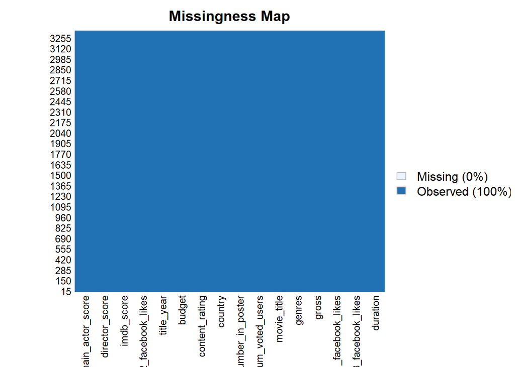

```r
missmap(data_cleaned)
```

```r
data_cleaned %>% summarise_all(funs(mean(is.na(.))))
```

```
## # A tibble: 1 x 16
##   duration actor_3_faceboo~ actor_1_faceboo~ gross genres movie_title
##      <dbl>            <dbl>            <dbl> <dbl>  <dbl>       <dbl>
## 1        0                0                0     0      0           0
## # ... with 10 more variables: num_voted_users <dbl>,
## #   facenumber_in_poster <dbl>, country <dbl>, content_rating <dbl>,
## #   budget <dbl>, title_year <dbl>, actor_2_facebook_likes <dbl>,
## #   imdb_score <dbl>, director_score <dbl>, main_actor_score <dbl>
```

No more NAs !

```r
dim(data_cleaned)
```

```
## [1] 3345   16
```

```r
nrow(data_cleaned) / nrow(data) * 100
```

```
## [1] 66.92677
```

We keep ~67% of our data !

Let’s visualize the impact of the cleaning procedure:

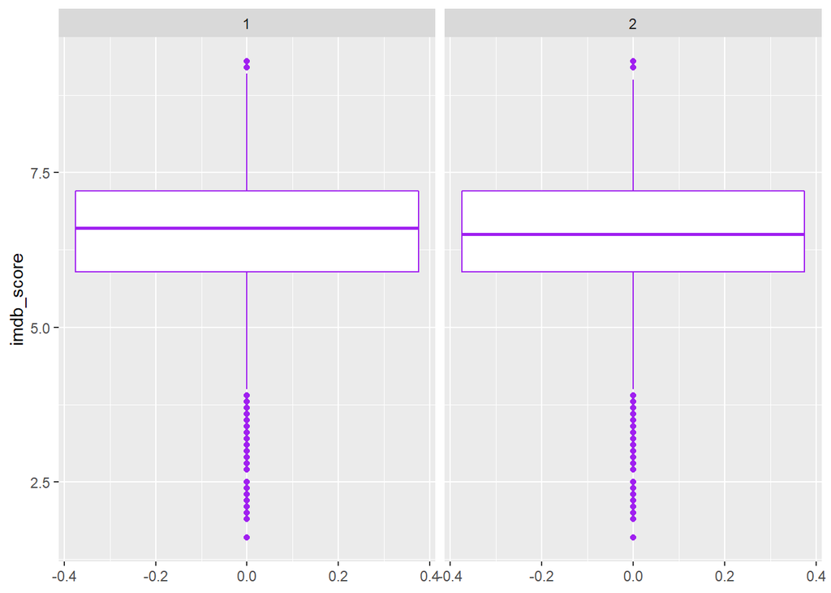

```r
comparing = data %>% select(imdb_score, gross)  %>% filter(!is.na(gross)) %>%
            bind_rows(data_cleaned %>% select(imdb_score, gross), .id="dataset")
ggplot(comparing)+aes(y=imdb_score)+geom_boxplot(color="purple")+facet_wrap(~dataset)
```

```r
summary(data$imdb_score);summary(data_cleaned$imdb_score)
```

```
##    Min. 1st Qu.  Median    Mean 3rd Qu.    Max.
##   1.600   5.800   6.600   6.441   7.200   9.500
```

```
##    Min. 1st Qu.  Median    Mean 3rd Qu.    Max.
##   1.600   5.900   6.500   6.442   7.200   9.300
```

```r
print("/n")
```

```
## [1] "/n"
```

```r
summary(data$gross);summary(data_cleaned$gross)
```

```
##      Min.   1st Qu.    Median      Mean   3rd Qu.      Max.      NA's
##       162   5304835  25445749  48325649  62319416 760505847       874
```

```
##      Min.   1st Qu.    Median      Mean   3rd Qu.      Max.
##       703   9180275  31146570  53248950  68750000 760505847
```

Looks like we preserved a good representation of our data !

```r
head(data);head(data_cleaned)
```

```
##   color     director_name num_critic_for_reviews duration
## 1 Color     James Cameron                    723      178
## 2 Color    Gore Verbinski                    302      169
## 3 Color        Sam Mendes                    602      148
## 4 Color Christopher Nolan                    813      164
## 5  <NA>       Doug Walker                     NA       NA
## 6 Color    Andrew Stanton                    462      132
##   director_facebook_likes actor_3_facebook_likes     actor_2_name
## 1                       0                    855 Joel David Moore
## 2                     563                   1000    Orlando Bloom
## 3                       0                    161     Rory Kinnear
## 4                   22000                  23000   Christian Bale
## 5                     131                     NA       Rob Walker
## 6                     475                    530  Samantha Morton
##   actor_1_facebook_likes     gross                          genres
```

[output cut: 55 more lines]

```
## # A tibble: 6 x 16
##   duration actor_3_faceboo~ actor_1_faceboo~  gross genres movie_title
##      <dbl>            <dbl>            <dbl>  <int> <fct>  <chr>
## 1      178              855             1000 7.61e8 Actio~ Avatar
## 2      169             1000            40000 3.09e8 Actio~ Pirates of~
## 3      164            23000            27000 4.48e8 Actio~ The Dark K~
## 4      132              530              640 7.31e7 Actio~ John Carte~
## 5      156             4000            24000 3.37e8 Actio~ Spider-Man~
## 6      100              284              799 2.01e8 Adven~ Tangled
## # ... with 10 more variables: num_voted_users <int>,
## #   facenumber_in_poster <int>, country <fct>, content_rating <fct>,
## #   budget <dbl>, title_year <int>, actor_2_facebook_likes <dbl>,
## #   imdb_score <dbl>, director_score <dbl>, main_actor_score <dbl>
```

## C) MONETARY VALUES : conversion to dollars and taking in count inflation

We have 2 values to convert in dollar/correct from inflation: gross and budget

We will base our study on 2019 US$.

```r
inflationdb=read.csv(url('http://suberalex.com/inflation_US.csv'), sep="\t") # Inflation rates for US $ from 1914 to 2018
inflationdb=inflationdb %>% select(Year,Annual)
year2019=2019
EURUSrate=1.15 #as of 1st january 2019, 1 EUR is equal to 1.15 USD
POUNDUSrate=1.25 #as of 1st january 2019, 1 GBP is equal to 1.25 USD
```

```r
actualizationf= function (value,year,targetyear,db) {
n=targetyear-year
for (i in 1:n) {
  value=value*(1+db[n+1-i,2]/100) #Actualization function
}
value
}
```

```r
#Monetary conversion
data_cleaned_a=data_cleaned %>% mutate(budget=ifelse(country=="USA",budget,ifelse(country=="UK",budget*POUNDUSrate,budget*EURUSrate)),gross=ifelse(country=="USA",gross,ifelse(country=="UK",gross*POUNDUSrate,gross*EURUSrate)))
#Actualization
data_cleaned_a=data_cleaned %>%  rowwise() %>% mutate(budget=sapply(budget,actualizationf,year=title_year,targetyear=2019,db=inflationdb)) %>% mutate(gross=sapply(gross,actualizationf,year=title_year,targetyear=2019,db=inflationdb)) %>%
  ungroup()
```

Adding a new category “ROI” and “profit” that will be useful for later

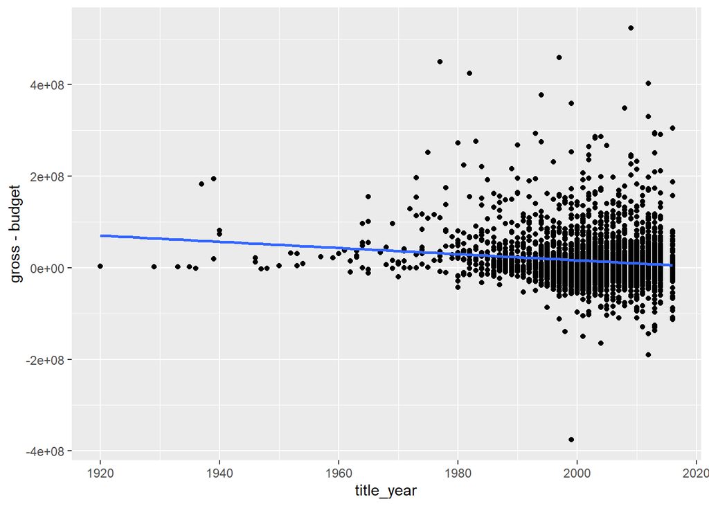

```r
data_cleaned_a=data_cleaned_a %>% mutate(ROI=gross/budget,profit=gross-budget)

data_cleaned=data_cleaned %>% mutate(ROI=gross/budget)

ggplot(data_cleaned)+aes(y=gross-budget,x=title_year)+geom_point()+geom_smooth(method="lm",se=F)
```

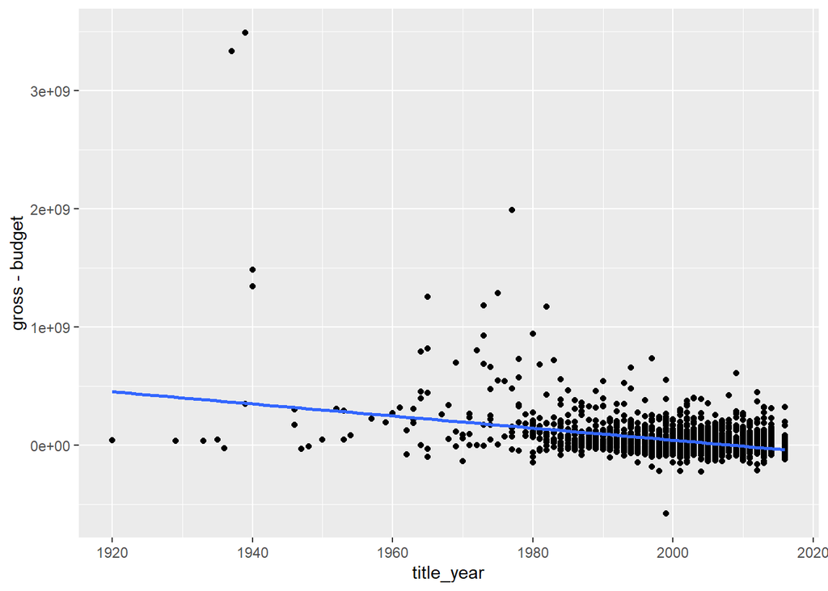

```r
ggplot(data_cleaned_a)+aes(y=gross-budget,x=title_year)+geom_point()+geom_smooth(method="lm",se=F)
```

We have now a better view on the different monetary values in our dataset.

Let’s check with the highest gross movie on our dataset:

```r
data_cleaned_a$movie_title[which.max(data_cleaned_a$gross)]
```

```
## [1] "Gone with the Wind "
```

It seems to be a great estimation of the adjusted profit of our dataset.“Gone with the Wind” is indeed the top 1 film worldwide when we adjust for inflation.

Source: https://www.cnbc.com/2019/07/22/top-10-films-at-the-box-office-when-adjusted-for-inflation.html

## D) Processing genres

We have a lot of genres and we need to create dummy variables according to those genres. However, we will focus on the top 10 most represented genres so that we won’t have too much dummy variables.

```r
TOP_N=10
genres = data_cleaned_a %>% group_by(genres)  %>% summarise(count=n()) %>%
  separate(col=genres, sep="\\|", into=c("GenreA", "GenreB", "GenreC")) %>%
  gather(key=genre_num, value=genre, -count) %>%
  group_by(genre) %>% summarise(count=sum(count)) %>%
  filter(!is.na(genre)) %>% ungroup() %>%
  top_n(TOP_N, count)
genres
```

```
## # A tibble: 10 x 2
##    genre     count
##    <chr>     <int>
##  1 Action      824
##  2 Adventure   681
##  3 Comedy     1333
##  4 Crime       612
##  5 Drama      1614
##  6 Fantasy     318
##  7 Horror      324
##  8 Romance     610
##  9 Sci-Fi      276
## 10 Thriller    520
```

```r
movies_genre = data_cleaned_a %>% select(movie_title, budget,imdb_score,title_year, all_genres=genres)
for (genre in genres$genre) {
  movies_genre = movies_genre %>% mutate(!!genre := as.numeric(grepl(genre, all_genres)))
}
#write.csv(movies_genre, "movies_genre.csv")
```

```r
movies_genre
```

```
## # A tibble: 3,345 x 15
##    movie_title budget imdb_score title_year all_genres Action Adventure Comedy
##    <chr>        <dbl>      <dbl>      <int> <fct>       <dbl>     <dbl>  <dbl>
##  1 Avatar      2.76e8        7.9       2009 Action|Ad~      1         1      0
##  2 Pirates of~ 3.74e8        7.1       2007 Action|Ad~      1         1      0
##  3 The Dark K~ 2.79e8        8.5       2012 Action|Th~      1         0      0
##  4 John Carte~ 2.94e8        6.6       2012 Action|Ad~      1         1      0
##  5 Spider-Man~ 3.21e8        6.2       2007 Action|Ad~      1         1      0
##  6 Tangled     3.04e8        7.8       2010 Adventure~      0         1      1
##  7 Harry Pott~ 2.92e8        7.5       2009 Adventure~      0         1      0
##  8 Batman v S~ 2.65e8        6.9       2016 Action|Ad~      1         1      0
##  9 Superman R~ 2.69e8        6.1       2006 Action|Ad~      1         1      0
## 10 Quantum of~ 2.42e8        6.7       2008 Action|Ad~      1         1      0
## # ... with 3,335 more rows, and 7 more variables: Crime <dbl>, Drama <dbl>,
## #   Fantasy <dbl>, Horror <dbl>, Romance <dbl>, `Sci-Fi` <dbl>, Thriller <dbl>
```

# II) Data Visualization

## A) IMDB Score

### > Global view

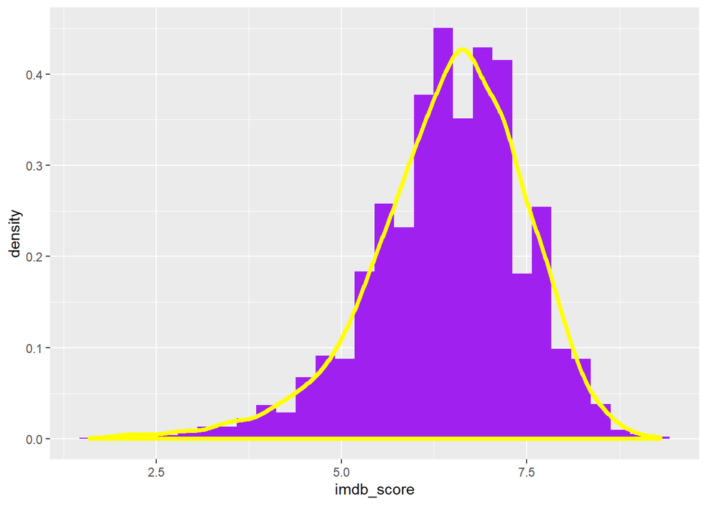

```r
ggplot(data_cleaned_a)+aes(x=imdb_score,y = ..density..)+ geom_histogram(bins=30,fill="Purple")+geom_density(size=1.5,color="yellow")
```

```r
  scale_x_continuous(name = "IMDB Score",
                     breaks = seq(0,10),
                     limits=c(1, 10))
```

```
## <ScaleContinuousPosition>
##  Range:
##  Limits:    1 --   10
```

### > by country

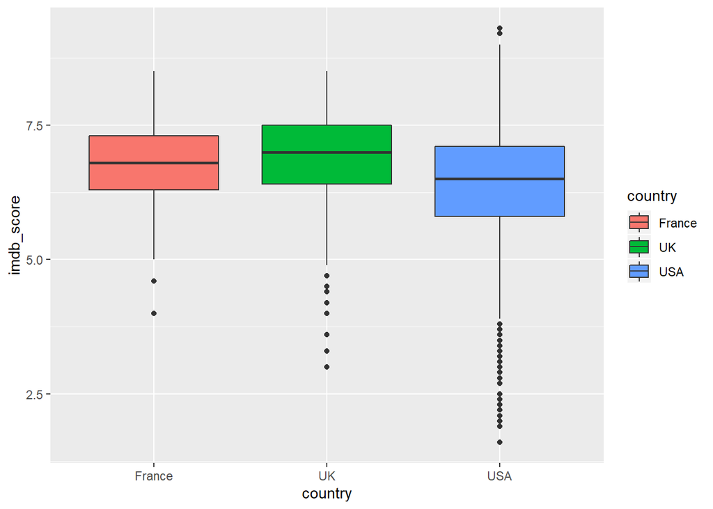

```r
ggplot(data_cleaned_a)+aes(x=country,y=imdb_score,fill=country)+
  geom_boxplot()
```

### > by content_rating

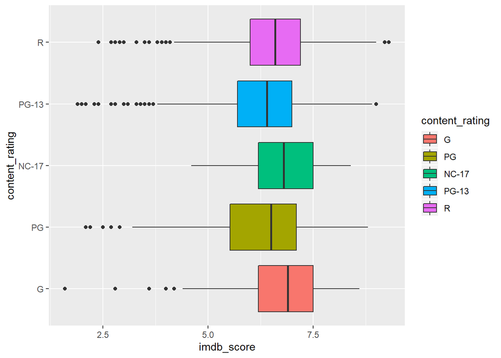

```r
ggplot(data_cleaned_a)+aes(x=content_rating,y=imdb_score,fill=content_rating)+
  geom_boxplot()+coord_flip()
```

### > facebook like vs imdb score

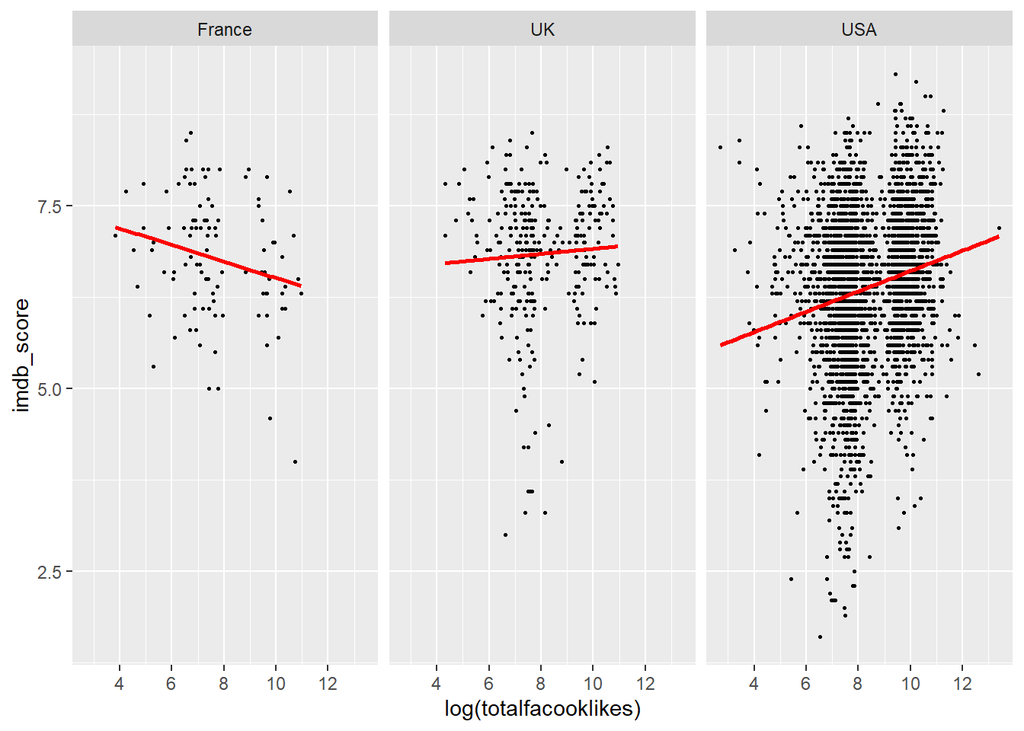

```r
data_cleaned_a%>%mutate(totalfacooklikes=actor_1_facebook_likes+actor_2_facebook_likes+actor_3_facebook_likes)%>%
  ggplot()+
  aes(x=log(totalfacooklikes),y=imdb_score)+
  geom_point(size=0.5)+
  geom_smooth(method="lm",se=F,color="red")+
  facet_wrap(~country,ncol = 3)
```

### > By genres

```r
movies_genre%>%gather(key="genre",value="value",-movie_title,-budget,-imdb_score,-title_year,-all_genres)%>%group_by(genre)%>%summarise(mean_genre=mean(value))%>%arrange(-mean_genre)
```

```
## # A tibble: 10 x 2
##    genre     mean_genre
##    <chr>          <dbl>
##  1 Drama          0.492
##  2 Comedy         0.404
##  3 Thriller       0.291
##  4 Action         0.246
##  5 Romance        0.232
##  6 Adventure      0.204
##  7 Crime          0.187
##  8 Fantasy        0.135
##  9 Sci-Fi         0.126
## 10 Horror         0.100
```

TOP6 Drama Comedy Thriller Action Romance Adventure

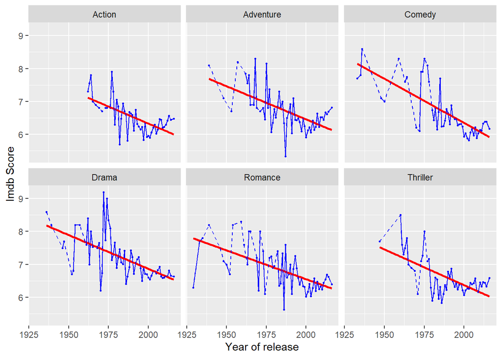

```r
movies_genre%>%select(-movie_title,-budget,-all_genres)%>%
  filter(title_year>1925)%>%
  gather(key="genre",value="value",-imdb_score,-title_year)%>%
  filter(grepl("(Drama|Comedy|Thriller|Action|Romance|Adventure)",genre))%>%
  mutate(imdb_score_genre=imdb_score*value)%>%
  group_by(genre,title_year)%>%
  summarise(imdb_score_year=mean(replace(imdb_score_genre, imdb_score_genre==0, NA), na.rm = T))%>%mutate(missing=interp1(title_year,imdb_score_year,title_year,"linear"))%>%
  ggplot()+
  aes(x=title_year,y=imdb_score_year)+
  geom_line(na.rm=T,color="blue")+
  geom_point(na.rm=T,color="blue",size=0.5)+
  geom_smooth(method="lm",se=F,color="red",na.rm=T)+
  geom_line(aes(x=title_year,y=missing),na.rm=T,color="blue",linetype="dashed",size=0.5)+
  xlab("Year of release")+
  ylab("Imdb Score")+
  facet_wrap(~genre,ncol=3,nrow=2)
```

We can see that for each kind of movie, there is a negative impact of the year for the IMDB predict score. It might be because when someone is reviewing an old movie, he’s less likely to give a bad grade because reviewers of old movies are most likely to be already fans.

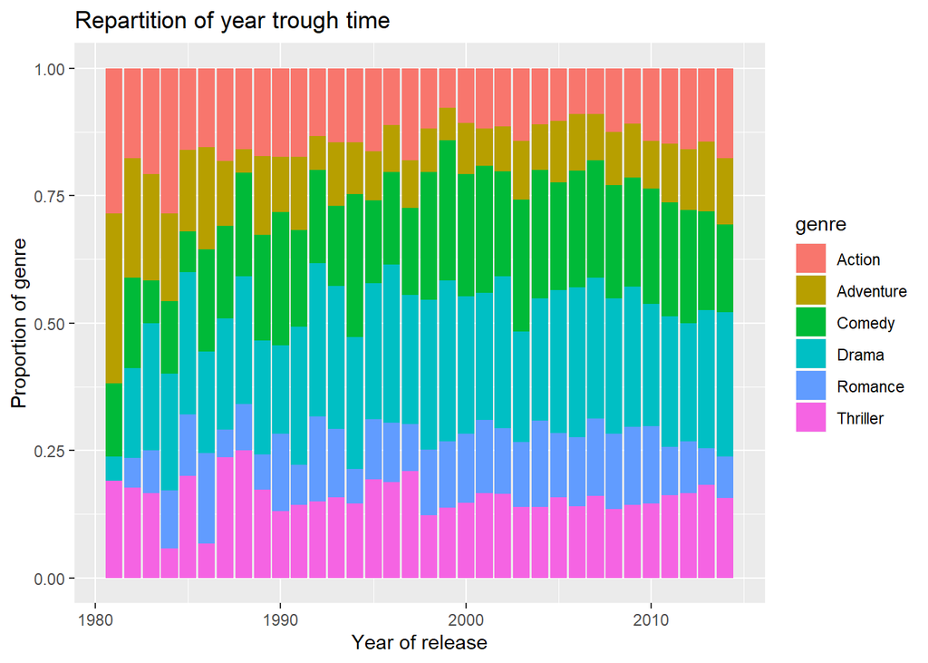

```r
movies_genre%>%select(-movie_title,-budget,-all_genres)%>%
  gather(key="genre",value="value",-imdb_score,-title_year)%>%
  filter(title_year>1980&title_year<2015)%>%
  filter(grepl("(Drama|Comedy|Thriller|Action|Romance|Adventure)",genre))%>%
  group_by(genre,title_year)%>%
  summarise(numberofmovie=sum(value))%>%
  ggplot()+
  aes(x=title_year,y=numberofmovie,fill=genre)+
  xlab("Year of release")+
  ylab("Proportion of genre")+
  ggtitle("Repartition of year trough time")+
  geom_bar(stat = "identity",position="fill")
```

### > By duration

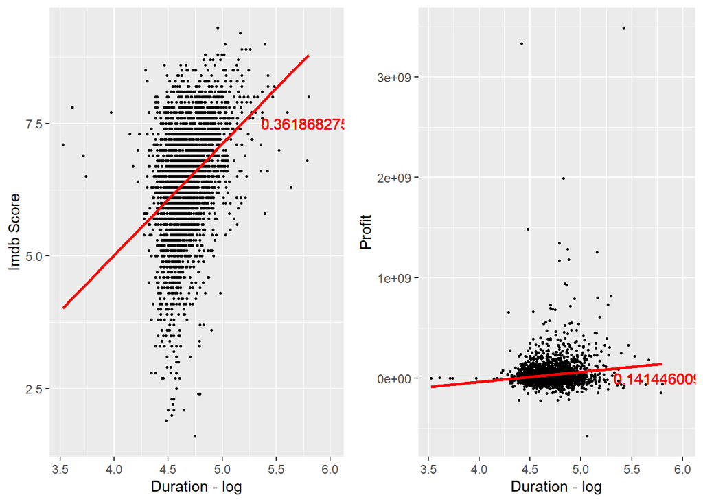

```r
p1=data_cleaned_a%>% select(imdb_score, duration)%>%
  ggplot()+
  aes(x=log(duration),y=imdb_score)+
  geom_point(size=0.5)+
  geom_smooth(method="lm",se=F,color="red")+
  geom_text(aes(6,7.5,label=cor(duration, imdb_score)),color="red")+
  xlab("Duration - log")+
  ylab("Imdb Score")
p2=data_cleaned_a%>% select(profit, duration)%>%
  ggplot()+
  aes(x=log(duration),y=profit)+
  geom_point(size=0.5)+
  geom_smooth(method="lm",se=F,color="red")+
  geom_text(aes(6,6,label=cor(duration, profit)),color="red")+
  xlab("Duration - log")+
  ylab("Profit")
grid.arrange(p1, p2, nrow = 1)
```

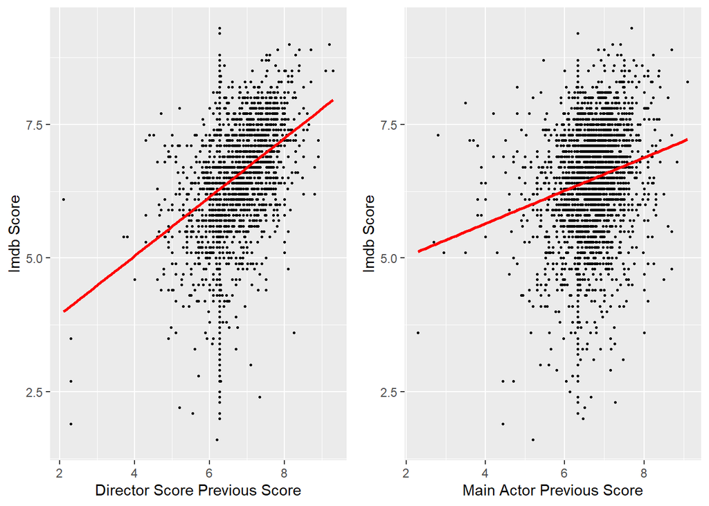

```r
p3<-ggplot(data_cleaned)+
  aes(x=director_score,y=imdb_score)+
  geom_point(size=0.5)+geom_smooth(method="lm",se=F,color="red")+
  xlab("Director Score Previous Score")+
  ylab("Imdb Score")
p4<-ggplot(data_cleaned)+
  aes(x=main_actor_score,y=imdb_score)+
  geom_point(size=0.5)+geom_smooth(method="lm",se=F,color="red")+
  xlab("Main Actor Previous Score")+
  ylab("Imdb Score")
grid.arrange(p3, p4, nrow = 1)
```

## B) GROSS vs IMDB Score

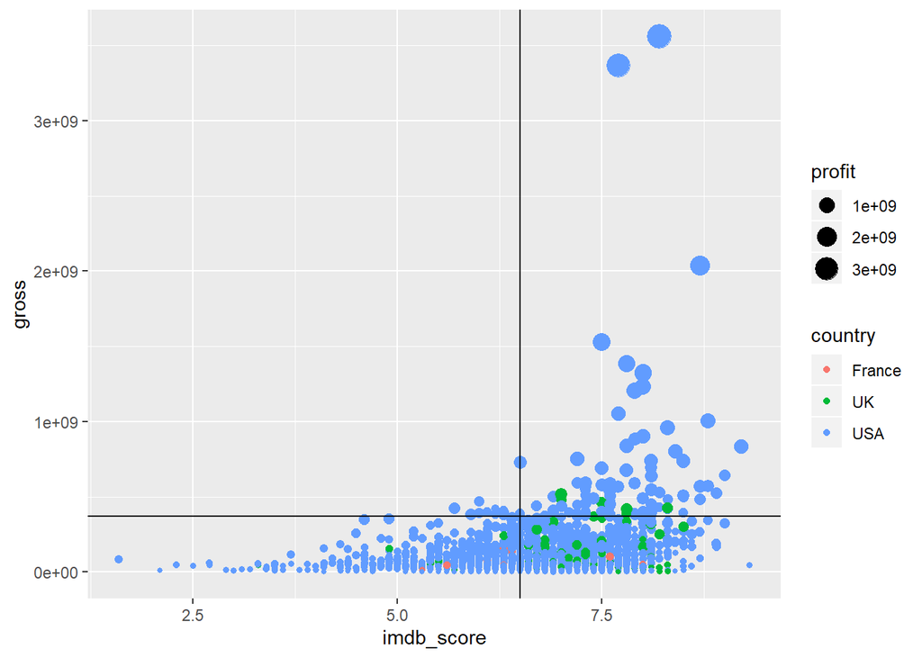

```r
data_cleaned_a%>%mutate(profit=(gross-budget))%>%top_n(profit,100) %>% ggplot()+
  aes(x=imdb_score,y=gross,size=profit,color=country)+
  geom_point()+
  geom_hline(aes(yintercept = 3.7e+08)) +
  geom_vline(aes(xintercept = 6.5))
```

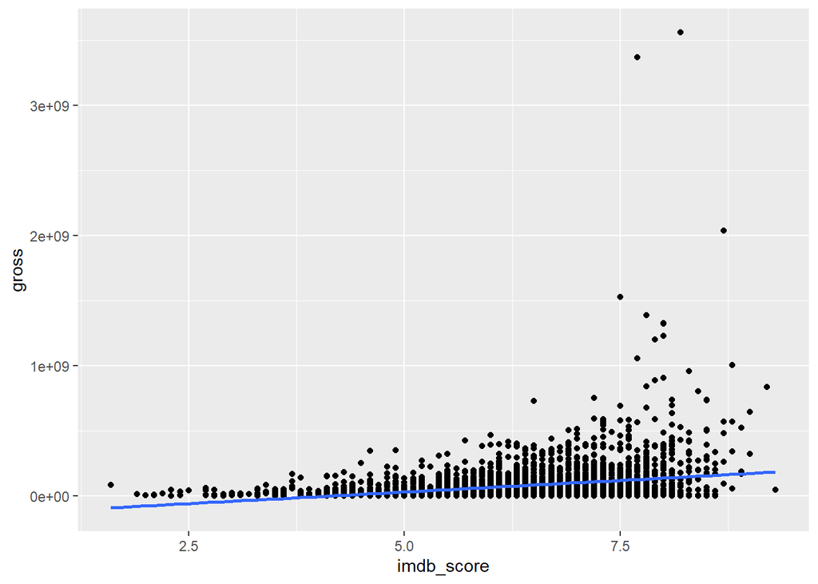

```r
ggplot(data_cleaned_a)+aes(y=gross,x=imdb_score)+geom_point()+geom_smooth(method="lm",se=F)
```

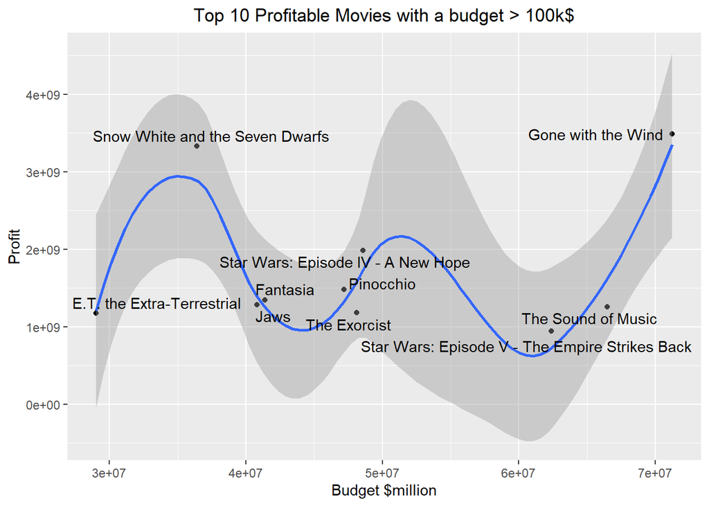

```r
data_cleaned_a %>%
  filter(budget > 100000) %>%
  arrange(desc(gross-budget)) %>%
  top_n(10, gross-budget) %>%
  ggplot(aes(x=budget, y=gross-budget)) +
  geom_point() +
  geom_smooth() +
  geom_text_repel(aes(label=movie_title)) +
  labs(x = "Budget $million", y = "Profit", title = "Top 10 Profitable Movies with a budget > 100k$") +
  theme(plot.title = element_text(hjust = 0.5))
```

# III) A REGRESSION PROBLEM: can we predict a film’s IMDB score ? - Linear Model and subset selection

First task: predicting the film’s IMDB score before its debut: therefore for this task we will not use - the gross - the number of users who votes on IMDB

We select only the variables that will be interesting for predicting imdb score.

```r
data.imdb= data_cleaned_a %>%
  left_join(movies_genre, by=c("movie_title", "budget", "title_year", "imdb_score")) %>%
  select(-all_genres, -genres, -gross, -movie_title, -num_voted_users,-profit,-director_score,-main_actor_score)
```

We are going to perform a *subset selection* to select the best linear models we can have with our data with a stepwise fit.

We split the data into 2 a training dataset of 75% of the data and a test dataset of 25% of the dataset

```r
set.seed(1234)
n=nrow(data.imdb)
samp <- sample(n)
i.train <- samp[1:round(0.75*n)]
i.test <- samp[-c(1:round(0.75*n))]
train <- data.imdb[i.train,]
test <- data.imdb[i.test,]
```

```r
linearmodel.imdb=lm(imdb_score~.,data=train)
```

```r
summary(linearmodel.imdb)
```

```
##
## Call:
## lm(formula = imdb_score ~ ., data = train)
##
## Residuals:
##     Min      1Q  Median      3Q     Max
## -4.2810 -0.4855  0.0808  0.5751  2.5959
##
## Coefficients:
##                          Estimate Std. Error t value Pr(>|t|)
## (Intercept)             2.406e+01  3.929e+00   6.123 1.06e-09 ***
## duration                1.165e-02  1.020e-03  11.429  < 2e-16 ***
## actor_3_facebook_likes  8.562e-06  1.172e-05   0.730 0.465318
## actor_1_facebook_likes  3.697e-06  1.105e-06   3.345 0.000836 ***
## facenumber_in_poster   -3.903e-02  9.560e-03  -4.083 4.58e-05 ***
## countryUK               8.815e-02  1.251e-01   0.705 0.481133
## countryUSA             -2.541e-01  1.120e-01  -2.269 0.023329 *
## content_ratingPG       -3.287e-01  1.046e-01  -3.142 0.001700 **
## content_ratingNC-17     1.713e-01  1.691e-01   1.013 0.311150
## content_ratingPG-13    -3.681e-01  1.050e-01  -3.505 0.000465 ***
## content_ratingR        -2.126e-02  1.050e-01  -0.202 0.839638
## budget                  6.783e-10  4.450e-10   1.524 0.127559
## title_year             -9.177e-03  1.957e-03  -4.688 2.90e-06 ***
## actor_2_facebook_likes  1.183e-05  4.663e-06   2.536 0.011258 *
## ROI                     1.730e-04  1.126e-04   1.537 0.124489
## Action                 -1.940e-01  5.173e-02  -3.749 0.000181 ***
## Adventure               5.026e-02  5.732e-02   0.877 0.380669
## Comedy                 -2.145e-01  4.670e-02  -4.593 4.57e-06 ***
## Crime                   3.472e-03  5.301e-02   0.065 0.947788
## Drama                   2.520e-01  4.550e-02   5.538 3.37e-08 ***
## Fantasy                -1.009e-01  5.625e-02  -1.793 0.073097 .
## Horror                 -4.707e-01  7.029e-02  -6.696 2.62e-11 ***
## Romance                -1.431e-01  4.536e-02  -3.153 0.001632 **
## `Sci-Fi`               -1.039e-02  5.869e-02  -0.177 0.859526
## Thriller               -1.932e-01  4.928e-02  -3.920 9.07e-05 ***
## ---
## Signif. codes:  0 '***' 0.001 '**' 0.01 '*' 0.05 '.' 0.1 ' ' 1
##
## Residual standard error: 0.903 on 2562 degrees of freedom
## Multiple R-squared:  0.2521, Adjusted R-squared:  0.2451
## F-statistic: 35.98 on 24 and 2562 DF,  p-value: < 2.2e-16
```

```r
#We select all the statistically significant variables
selected=summary(linearmodel.imdb)$coeff[-1,4] < 0.05
# select sig. variables
relevant <- names(selected)[selected == TRUE]
relevant[5]="content_rating"
relevant=relevant[-c(4,6)]

# formula with only sig variables
formula <- as.formula(paste("imdb_score ~",paste(relevant, collapse= "+")))
linearmodel.imdb.rel=lm(formula=formula,data=train)
#summary(linearmodel.imdb.rel)

#Select columns on train

train2=train %>% select(imdb_score,relevant)
test2=test %>% select(imdb_score,relevant)
mod.sel <- regsubsets(imdb_score~.,data=train2)
summary(mod.sel)
```

```
## Subset selection object
## Call: regsubsets.formula(imdb_score ~ ., data = train2)
## 15 Variables  (and intercept)
##                        Forced in Forced out
## duration                   FALSE      FALSE
## actor_1_facebook_likes     FALSE      FALSE
## facenumber_in_poster       FALSE      FALSE
## content_ratingPG           FALSE      FALSE
## content_ratingNC-17        FALSE      FALSE
## content_ratingPG-13        FALSE      FALSE
## content_ratingR            FALSE      FALSE
## title_year                 FALSE      FALSE
## actor_2_facebook_likes     FALSE      FALSE
## Action                     FALSE      FALSE
## Comedy                     FALSE      FALSE
## Drama                      FALSE      FALSE
## Horror                     FALSE      FALSE
## Romance                    FALSE      FALSE
## Thriller                   FALSE      FALSE
## 1 subsets of each size up to 8
## Selection Algorithm: exhaustive
##          duration actor_1_facebook_likes facenumber_in_poster content_ratingPG
## 1  ( 1 ) "*"      " "                    " "                  " "
## 2  ( 1 ) "*"      " "                    " "                  " "
## 3  ( 1 ) "*"      " "                    " "                  " "
## 4  ( 1 ) "*"      " "                    " "                  " "
## 5  ( 1 ) "*"      " "                    " "                  " "
## 6  ( 1 ) "*"      " "                    "*"                  "*"
## 7  ( 1 ) "*"      " "                    " "                  "*"
## 8  ( 1 ) "*"      "*"                    "*"                  "*"
##          content_ratingNC-17 content_ratingPG-13 content_ratingR title_year
## 1  ( 1 ) " "                 " "                 " "             " "
## 2  ( 1 ) " "                 " "                 " "             " "
## 3  ( 1 ) " "                 "*"                 " "             " "
## 4  ( 1 ) " "                 "*"                 " "             " "
## 5  ( 1 ) " "                 "*"                 " "             " "
## 6  ( 1 ) " "                 "*"                 " "             " "
## 7  ( 1 ) " "                 "*"                 " "             " "
## 8  ( 1 ) " "                 "*"                 " "             "*"
##          actor_2_facebook_likes Action Comedy Drama Horror Romance Thriller
## 1  ( 1 ) " "                    " "    " "    " "   " "    " "     " "
## 2  ( 1 ) " "                    " "    " "    "*"   " "    " "     " "
## 3  ( 1 ) " "                    " "    " "    "*"   " "    " "     " "
## 4  ( 1 ) " "                    " "    " "    "*"   "*"    " "     " "
## 5  ( 1 ) " "                    " "    "*"    "*"   "*"    " "     " "
## 6  ( 1 ) " "                    " "    " "    "*"   "*"    " "     " "
## 7  ( 1 ) " "                    " "    "*"    "*"   "*"    " "     "*"
## 8  ( 1 ) " "                    " "    " "    "*"   "*"    " "     " "
```

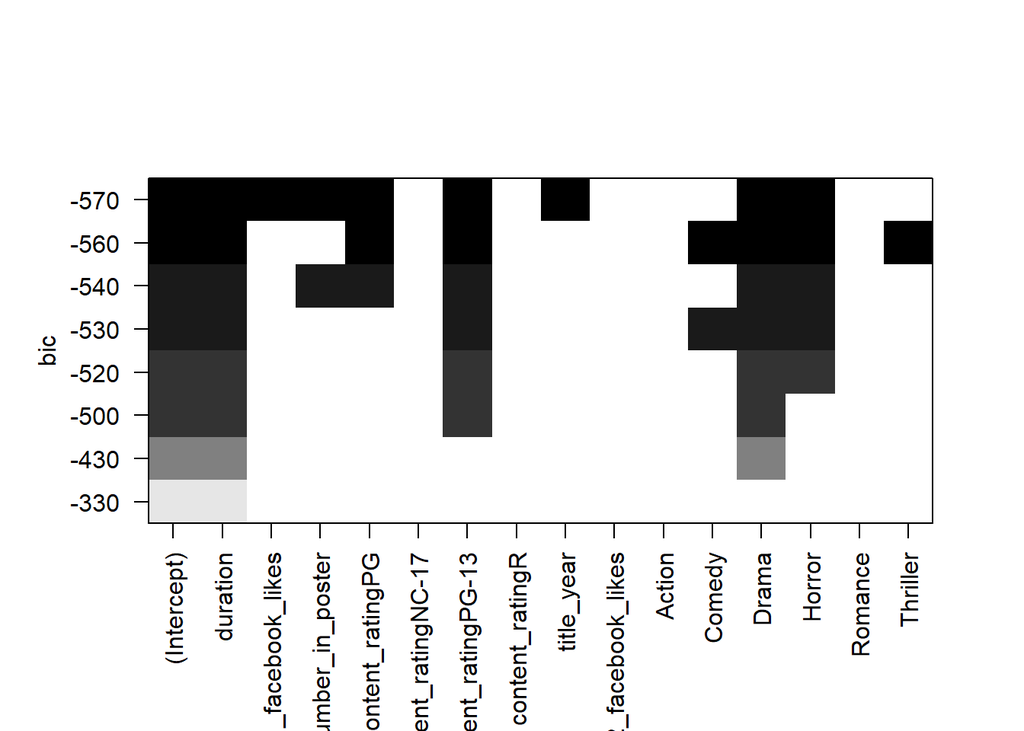

```r
plot(mod.sel,scale="bic")
```

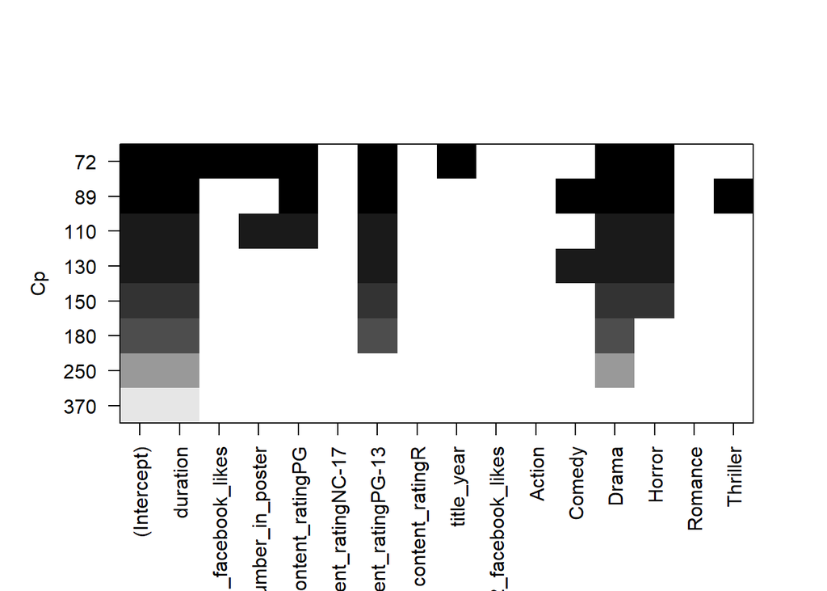

```r
plot(mod.sel,scale="Cp")
```

Both bic and cp models looks the same

```r
mod.biccp <- lm(imdb_score~duration+content_rating+Drama+Horror,data=train)

#Compute error
prev <- data.frame(Y=test2$imdb_score,lin=predict(linearmodel.imdb.rel,newdata=test2),BIC=predict(mod.biccp,newdata=test2))
prev %>% summarize(Err_lin=mean((Y-lin)^2),Err_BIC=mean((Y-BIC)^2))
```

```
##     Err_lin   Err_BIC
## 1 0.8093722 0.8546106
```

We have an error on the model selected that is higher than the one of the linear model. Also, the error rates are quite high on both models. The variable selection method seems then not to suit our approach of this dataset. Let’s try to use regularized methods. We saw the imdb_score, we are now going to perform go further with Lasso and Ridge methods for the gross on our imdb data set.

# IV) A REGRESSION PROBLEM: can we predict a film’s gross box office ? - regularized methods

First task: predicting the film’s gross before its debut: therefore for this task we will not use - the IMDB score - the number of users who votes on IMDB We also remove the movie title, and use our dummy variables to code for genre. Since the average gross box office is around 48M, we change this variable unit to be expressed in Million USD.

We rename columns with the hyphen “-” in their names to avoir subsequent errors. We create dummies for name variables.

We are likely to have a lot of dummies with underrepresented values and should be careful, especially since we intend to use successive cross validations. Let’s inspect our dummies:

```r
movies_genre %>% select(Action:"Thriller")  %>%
 apply(2, sum)
```

```
##    Action Adventure    Comedy     Crime     Drama   Fantasy    Horror   Romance
##       824       681      1350       626      1647       452       335       777
##    Sci-Fi  Thriller
##       423       972
```

```r
data.reg = data_cleaned_a %>%
  left_join(movies_genre, by=c("movie_title", "budget", "title_year", "imdb_score")) %>%
  select(-all_genres, -genres, -imdb_score, -movie_title, -num_voted_users, -profit, -ROI) %>%
  mutate(gross=gross/1e6) %>%
  rename(Sci_fi="Sci-Fi")
#We compute the dummies directly to avoid being annoyed by the knn reg function
data.reg = data.frame(model.matrix(lm(gross~., data=data.reg)))[,-1] %>%
           mutate(gross=data.reg$gross)
```

We will compare the performances of several learning algorithms on this task within an Empirical Risk Minimization Framework. **metric**: The risk of a model will be estimated with the Root Mean Squard Error.

**Evaluation Procedure** We are going to randomly split our data in a training, validation and test dataset. Every candidate model’s hyperparameters will be chosen with a cross validation done on the training dataset. The models will then be compared with a cross validation on the validation dataset. We will finally evaluate our best model’s performance on the test dataset. To increase the accuracy of the evaluation, we can repeat this procedure several times.

Finally, we will look at an example application of this model. Since we have more than 3000 individuals, we can split our data in a 50/40/10 ratio for training / validation / testing respectively.

Let’s define 2 functions for our metrics:

```r
RMSE = function(yobs, yhat) sqrt(mean((yhat - yobs)^2, na.rm=T))
MAPE = function(yobs, yhat) mean(abs((yhat - yobs)/yobs), na.rm=T)
```

And initialize the splitting:

```r
N_FOLD=10
set.seed(1235)
train.p = 0.5
val.p = 0.4
n = nrow(data.reg)
train = sample(n, round(train.p * n))
val = sample((1:n)[-train], round(val.p * n))
reg.train = data.reg %>% slice(train)
reg.val = data.reg %>% slice(val)
reg.test = data.reg %>% slice(-c(train, val))
n.train=nrow(reg.train)
n.val=nrow(reg.val)
```

Let’s start with a simple linear model with a stepwise selection algorithm. We use a backward selection process with a BIC criteria, and compare it to a regression k-Nearest Neighbors algorithm, following the procedure explained earlier.

```r
#Quick check: since we have a lot of dummy variables with under-represented values:
qr(reg.train)$rank == ncol(reg.train)
```

```
## [1] TRUE
```

Let’s initialize our parallel coputing tools for faster processing:

```r
#For faster computations
cl <- detectCores() %>% -1 %>% makeCluster
cl
```

```
## socket cluster with 7 nodes on host 'localhost'
```

```r
registerDoParallel(cl)
```

We start with simple models: * one full linear model * a linear model selected with a stepwise procedure from the full linear model * a kNN regression model

We will keep our tree at random:

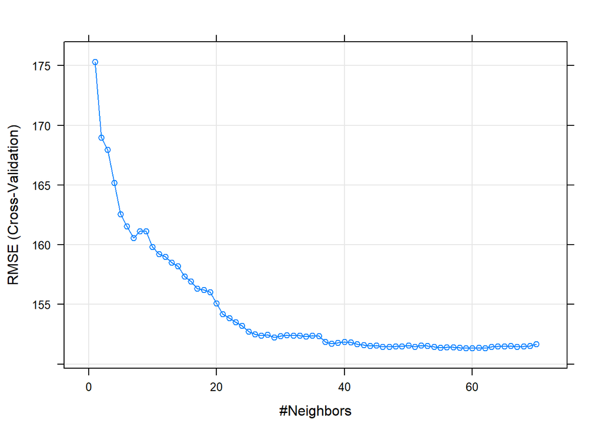

```r
#Selecting best linear model with a backward stepwise procedure on the trainoing data
full.linear.model = lm(gross~., data=reg.train)
model.step = step(full.linear.model, direction="backward", k=log(n.train), trace=0)

set.seed(12345)
#Initiating the cross validation method
ctrl.cv = trainControl(method="cv", number=N_FOLD)

#Selecting the best parameters with the cross validation
#Selecting the parameter "k" for kNN
grid.k = data.frame(k=seq(1,70,by=1))
sel.k = train(gross~., data=reg.train, method="knn", trControl=ctrl.cv, tuneGrid=grid.k)
plot(sel.k)
```

```r
best.k = which.min(sel.k$results$RMSE)
print(paste("Best k for k-NN: ", best.k))
```

```
## [1] "Best k for k-NN:  60"
```

```r
#Selecting the best parameter "cp" for a regression tree wth 10-fold cross validations
tree = rpart(gross~., data=reg.train, cp=0.00001, xval=N_FOLD, minsplit=2)
best.cp = tree$cptable %>% as.data.frame() %>%
  filter(xerror==min(xerror)) %>%
  select(CP) %>%
  as.numeric()
print(paste("Best cp for regression tree: ", best.cp))
```

```
## [1] "Best cp for regression tree:  0.0164087206152178"
```

```r
#Comparing algorithms
set.seed(1234)
folds = createFolds(1:n.val, k=N_FOLD)

result = foreach(fold=iter(folds), .packages=c("tidyverse", "caret", "rpart", "rpart.plot", "ranger"), .combine=rbind) %dopar% {

  val.train = reg.val %>% slice(-fold)
  val.test = reg.val %>% slice(fold)

  eval.df = data.frame(yhat.knn=NA, yhat.stepwise=NA, yhat.tree=NA, yhat.lm=NA,
                       yobs=val.test$gross)

  #Predicting with a simple full linear model
  lm =lm(gross~., data=val.train)
  eval.df$yhat.lm = predict(lm, newdata=val.test)

  #Predicting with stepwise selected linear model
  stepwise.lm = lm(model.step$call, data=val.train)
  eval.df$yhat.stepwise = predict(stepwise.lm, newdata=val.test)

  #Predicting with KNN, selected K
  eval.df$yhat.knn = knnregTrain(val.train, val.test, val.train$gross, k=best.k)

  #Predicting with a regression tree
  tree = rpart(gross~., data=val.train, cp=best.cp)
  best.tree = prune(tree, cp=best.cp)
  eval.df$yhat.tree = predict(best.tree, newdata=val.test)

  eval.df %>% summarise_all(funs(MAPE(yobs, .), RMSE(yobs, .))) %>%
    select(contains("yhat")) %>%
    gather(id, value) %>%
    separate(id, c("model", "metric"), sep="_") %>%
    spread(key=metric, value=value)

}

tab = result %>% group_by(model) %>%
  summarise(RMSE_sd=sd(RMSE), MAPE=mean(MAPE), RMSE=mean(RMSE))
tab
```

```
## # A tibble: 4 x 4
##   model         RMSE_sd  MAPE  RMSE
##   <chr>           <dbl> <dbl> <dbl>
## 1 yhat.knn         14.7  70.4  99.9
## 2 yhat.lm          14.6  70.1  90.1
## 3 yhat.stepwise    14.2  65.8  91.6
## 4 yhat.tree        18.3  97.2  91.7
```

There seems to be a lot of variance in our results.

Let’s look at our last best tree:

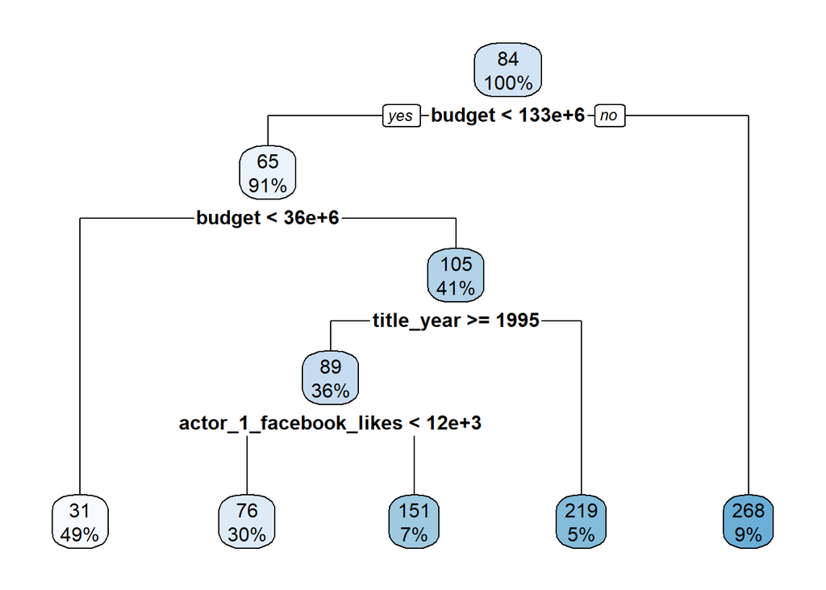

```r
tree = rpart(gross~., data=reg.val[folds[[10]],], cp=best.cp, model=T)
rpart.plot(prune(tree, cp=best.cp))
```

All our errors quite large, indicating that maybe the variables present in the data are not sufficient to correctly predict the gross of a movie. But can we try to decrease the variance of our prediction ? For this purpose, we evalute on the same task: * a random forest algorithm * a Ridge regression * a Lasso regression To keep our results comparable, we evaluate them on the same fold partition.

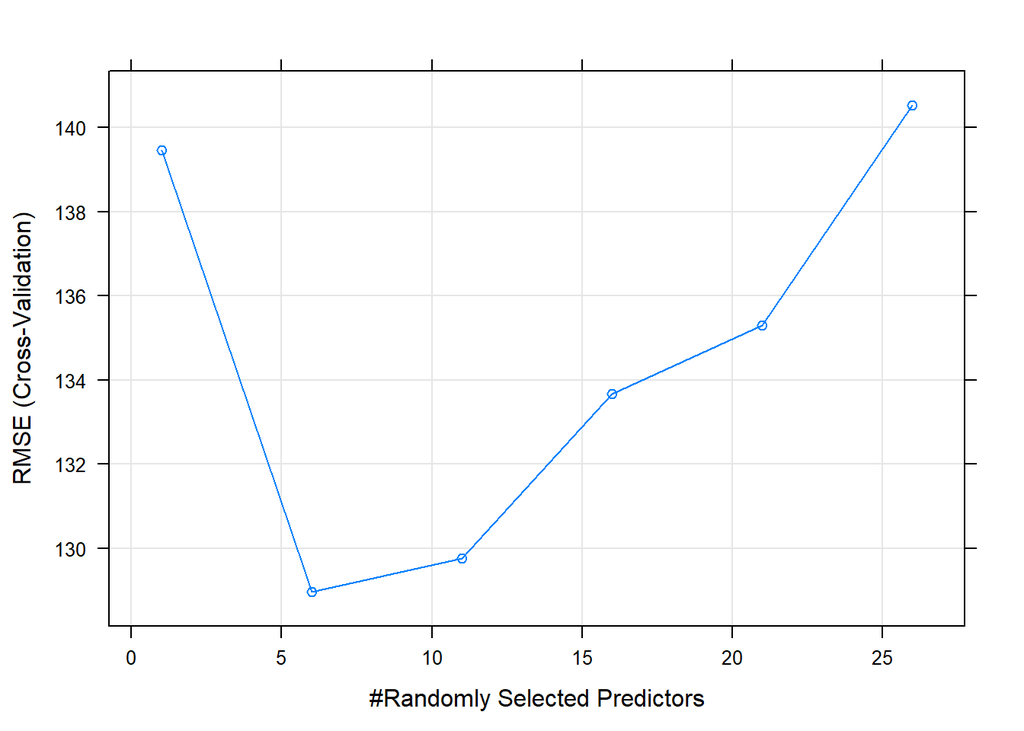

```r
#Selecting the best parameter "mtry" for a random forest regression with 10-fold cross validations
grid.mtry = data.frame(mtry=seq(1, 30, by=5))
sel.mtry = train(gross~., data=reg.train, method="rf", trControl=ctrl.cv, tuneGrid=grid.mtry)
plot(sel.mtry)
```

```r
best.mtry = sel.mtry$results$mtry[which.min(sel.mtry$results$RMSE)]
print(paste("Best mtry for Random Forest: ", best.mtry))
```

```
## [1] "Best mtry for Random Forest:  6"
```

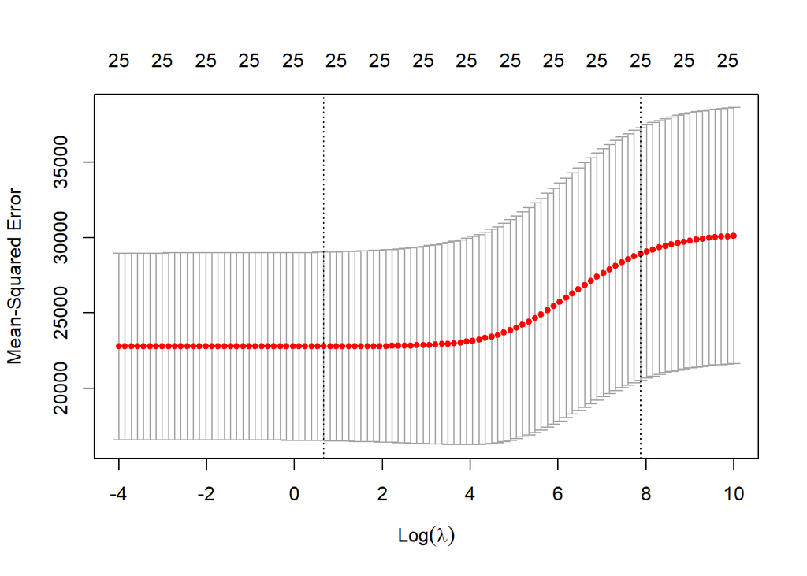

```r
set.seed(12)
#Selecting the best parameters for Ridge and Lasso Regressions
train.X = model.matrix(gross~., data=reg.train)[,-1]

ridge.k = cv.glmnet(train.X, reg.train$gross, alpha=0,
                    lambda=exp(seq(-4, 10,length=100)),
                    nfolds=N_FOLD)
plot(ridge.k)
```

```r
best.ridge.lambda = ridge.k$lambda.min
print(paste("Best lambda for Ridge Regression: ", best.ridge.lambda))
```

```
## [1] "Best lambda for Ridge Regression:  1.94773404105467"
```

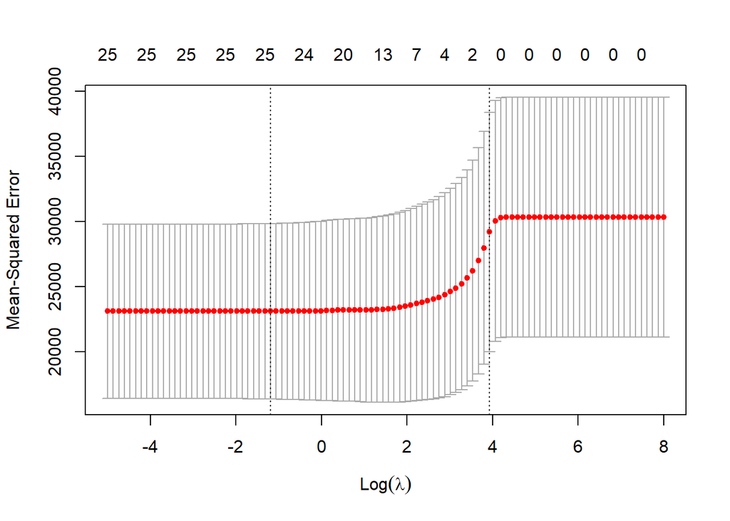

```r
lasso.k = cv.glmnet(train.X, reg.train$gross, alpha=1,
                    lambda=exp(seq(-5, 8,length=100)),
                    nfolds=N_FOLD)
plot(lasso.k)
```

```r
best.lasso.lambda = lasso.k$lambda.min
print(paste("Best lambda for Lasso Regression: ", best.lasso.lambda))
```

```
## [1] "Best lambda for Lasso Regression:  0.303637964985541"
```

```r
result2 = foreach(fold=iter(folds), .packages=c("tidyverse", "ranger"), .combine=rbind) %dopar% {
  library("glmnet")
  val.train = reg.val %>% slice(-fold)
  val.test = reg.val %>% slice(fold)
  train.X = model.matrix(gross~., data=val.train)[,-1]
  test.X = model.matrix(gross~., data=val.test)[,-1]

  eval.df = data.frame(yhat.rf=NA, yhat.ridge=NA, yhat.lasso=NA, yobs=val.test$gross)

  #Predicting with Random Forest
  rf = ranger(gross~.,data=val.train,mtry=best.mtry)
  eval.df$yhat.rf = predict(rf, data=val.test)[1]$predictions

  #¨Predictions with penalized regressions
  ridge=glmnet(train.X, val.train$gross, alpha=0, lambda=best.ridge.lambda)
  eval.df$yhat.ridge = predict(ridge, newx=test.X)

  lasso=glmnet(train.X, val.train$gross, alpha=1, lambda=best.lasso.lambda)
  eval.df$yhat.lasso = predict(lasso, newx=test.X)

  eval.df %>% summarise_all(funs(MAPE(yobs, .), RMSE(yobs, .))) %>%
    select(contains("yhat")) %>%
    gather(id, value) %>%
    separate(id, c("model", "metric"), sep="_") %>%
    spread(key=metric, value=value)

}

tab2 = result2 %>% group_by(model) %>%
  summarise(RMSE_sd=sd(RMSE), MAPE=mean(MAPE), RMSE=mean(RMSE))
tab2
```

```
## # A tibble: 3 x 4
##   model      RMSE_sd  MAPE  RMSE
##   <chr>        <dbl> <dbl> <dbl>
## 1 yhat.lasso    14.6  64.9  90.0
## 2 yhat.rf       13.5  65.5  82.8
## 3 yhat.ridge    14.6  67.1  90.0
```

Inspecting our last LASSO model

```r
train.X = model.matrix(gross~., data=reg.val[folds[[10]],])[,-1]
lasso=glmnet(train.X, reg.val$gross[folds[[10]]], alpha=1, lambda=best.lasso.lambda)
lasso$beta
```

```
## 25 x 1 sparse Matrix of class "dgCMatrix"
##                                   s0
## duration                9.788643e-01
## actor_3_facebook_likes  5.405553e-03
## actor_1_facebook_likes  3.544336e-03
## facenumber_in_poster    5.215055e+00
## countryUK              -2.086526e+01
## countryUSA              1.403856e+01
## content_ratingPG        6.915827e+01
## content_ratingNC.17     .
## content_ratingPG.13     1.391481e+01
## content_ratingR        -3.761754e+00
## budget                  7.442841e-07
## title_year             -3.224426e+00
## actor_2_facebook_likes  3.172834e-04
## director_score          5.326388e+00
## main_actor_score       -2.431332e+01
## Action                 -1.257570e+01
## Adventure               1.818179e+00
## Comedy                 -2.597189e+00
## Crime                  -2.747925e+01
## Drama                  -1.624038e+01
## Fantasy                -2.493300e+01
## Horror                  2.791882e+01
## Romance                -8.301950e+00
## Sci_fi                 -3.119311e+01
## Thriller                9.790826e+00
```

Our final results

```r
rbind(tab, tab2) %>% arrange(RMSE)
```

```
## # A tibble: 7 x 4
##   model         RMSE_sd  MAPE  RMSE
##   <chr>           <dbl> <dbl> <dbl>
## 1 yhat.rf          13.5  65.5  82.8
## 2 yhat.lasso       14.6  64.9  90.0
## 3 yhat.ridge       14.6  67.1  90.0
## 4 yhat.lm          14.6  70.1  90.1
## 5 yhat.stepwise    14.2  65.8  91.6
## 6 yhat.tree        18.3  97.2  91.7
## 7 yhat.knn         14.7  70.4  99.9
```

Not much variance reduction in penalized regressions … We have two good candidates: LASSO: very small MAPE, better than average RMSE Random Forest: very small RMSE, small variance.

Let’s chose the RANDOM FOREST model. Let’s train our chosen model and evaluate its performance on the test dataset.

```r
#Predicting with Random Forest
set.seed(123456)
reg.final = data.reg %>% slice(c(train, val))
model = ranger(gross~.,data=reg.final,mtry=best.mtry)
preds = predict(model, data=reg.test)[1]$predictions
RMSE(reg.test$gross, preds)
```

```
## [1] 110.4171
```

```r
MAPE(reg.test$gross, preds)
```

```
## [1] 32.70809
```

A concrete example: **The Avengers**: Let’s take a film from our test data.

```r
t(data_cleaned_a %>% filter(gross==reg.test$gross[1]*1e6))
```

```
##                        [,1]
## duration               "173"
## actor_3_facebook_likes "19000"
## actor_1_facebook_likes "26000"
## gross                  "695792122"
## genres                 "Action|Adventure|Sci-Fi"
## movie_title            "The Avengers "
## num_voted_users        "995415"
## facenumber_in_poster   "3"
## country                "USA"
## content_rating         "PG-13"
## budget                 "245594882"
## title_year             "2012"
## actor_2_facebook_likes "21000"
## imdb_score             "8.1"
## director_score         "8"
## main_actor_score       "6.875"
## ROI                    "2.833089"
## profit                 "450197240"
```

```r
preds[1]
```

```
## [1] 366.9221
```

We predicted a gross of 366M. Th film did a gross of 695M.

# V) A CLASSIFICATION PROBLEM

```
Guidelines for creating classes of movies:
```

We want to classify the movies according to 4 groups:

- Movies with good scores and good profits: These are the excellent movies with good earnings that reflect the critical and public acclaim they had (class A)
- Movies with good scores but bad profits: These are still good movies because they were well received by critics and to some extent the general population but didn’t do as well on theaters because of other reasons (class B)
- Movies with bad scores but good profits: ok movies that are still popular even if they are of poor quality (class D)
- Movies with bad scores and bad profits: these are the worst because they failed on theaters and scored bad (class F)

**For the profits, rather than using the gross, because it penalizes small budget and independant films, we are using the Return On Investment to create a new variable: ROI=GROSS/BUDGET** We’ll take a look at the means and medians of the variables SCORE and ROI to determine the threshold between good and bad.

```r
data.classification = data_cleaned_a %>% mutate(ROI=gross/budget)

summary(data.classification$ROI)
```

```
##     Min.  1st Qu.   Median     Mean  3rd Qu.     Max.
##    0.000    0.519    1.143    6.856    2.318 7194.486
```

** For the ROI we will take the median 1.143 as the threshold because the mean is affected by outliers

```r
summary(data.classification$imdb_score)
```

```
##    Min. 1st Qu.  Median    Mean 3rd Qu.    Max.
##   1.600   5.900   6.500   6.442   7.200   9.300
```

** For the score we set the threshold for 6.5 as we observe the median and mean are about the same.

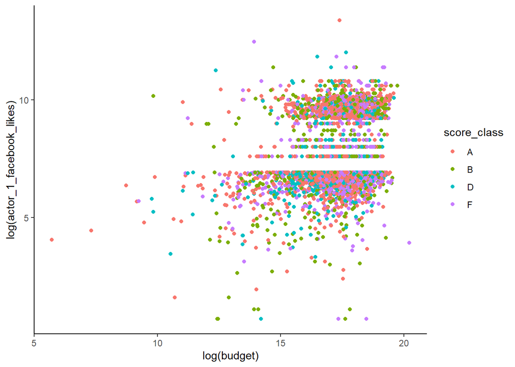

```r
data.classification=data.classification %>% mutate(score_class=ifelse(imdb_score<6.5 & ROI<1.143,"F",ifelse(imdb_score<6.5 & ROI>=1.143,"D",ifelse(imdb_score>=6.5 & ROI<1.143,"B","A"))))
data.classification$score_class=as.factor(data.classification$score_class)

ggplot(data.classification)+aes(y=log(actor_1_facebook_likes),x=log(budget),color=score_class)+geom_point()+theme_classic()
```

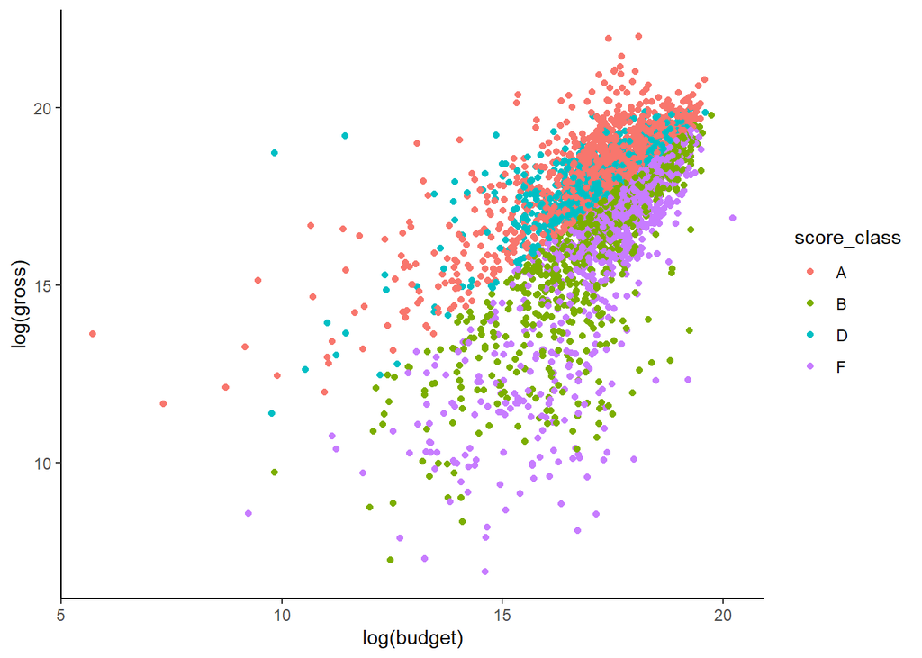

```r
ggplot(data.classification)+aes(y=log(gross),x=log(budget),color=score_class)+geom_point()+theme_classic()
```

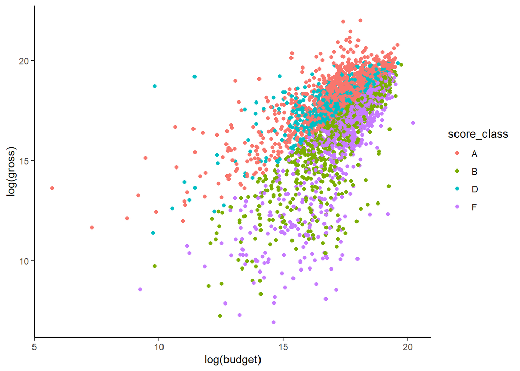

```r
ggplot(data.classification)+aes(y=log(gross),x=log(budget),color=score_class)+geom_point()+theme_classic()
```

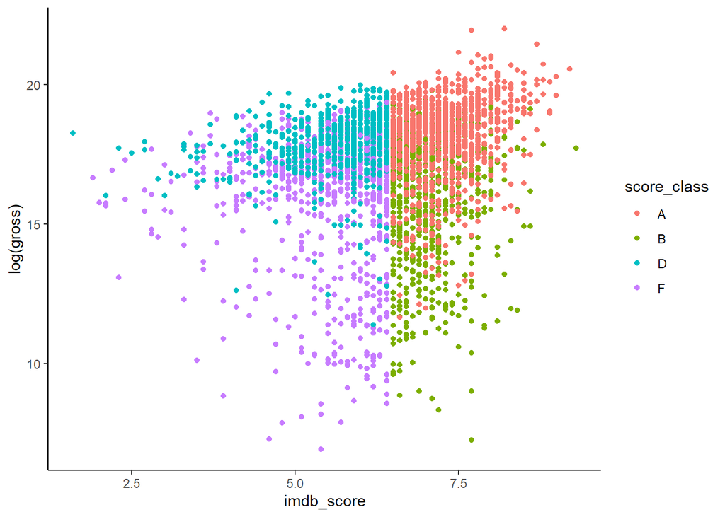

```r
ggplot(data.classification)+aes(x=imdb_score,y=log(gross),color=score_class)+geom_point()+theme_classic()
```

** For the classification problem, we will not use the following variables: - the ROI, the IMDB score, the gross and the budget because they were used to create the classes. - the actor and director scores because they are lineary dependent on the imdb_score - the profit because it depends on the budget and gross. - the number of users who votes on IMDB because we want to predict the class of the movie when it comes out. - the movie title because it’s irrelevant.

We will also use the same dummy variables to code for genre.

```r
data.classification = data.classification %>%
  left_join(movies_genre, by=c("movie_title", "budget", "title_year", "imdb_score")) %>%
  dplyr::select(-all_genres, -genres, -imdb_score, -movie_title, -num_voted_users, -profit, -budget, -gross, -ROI, -title_year, -director_score, -main_actor_score) %>%
  rename(Sci_fi="Sci-Fi")
data.classification=droplevels(data.classification)

#We will create dummy variables for the columns content_rating and country for the knn classification
library(fastDummies)
data.classification = dummy_cols(data.classification, select_columns = "content_rating")
data.classification = dummy_cols(data.classification, select_columns = "country")
data.classification = data.classification %>%
  dplyr::select(-content_rating)
data.classification = data.classification %>%
  dplyr::select(-country)
summary(data.classification)
```

```
##     duration     actor_3_facebook_likes actor_1_facebook_likes
##  Min.   : 34.0   Min.   :    2          Min.   :     2
##  1st Qu.: 95.0   1st Qu.:  221          1st Qu.:   774
##  Median :106.0   Median :  460          Median :  1000
##  Mean   :109.7   Mean   :  799          Mean   :  7995
##  3rd Qu.:120.0   3rd Qu.:  723          3rd Qu.: 13000
##  Max.   :330.0   Max.   :23000          Max.   :640000
##  facenumber_in_poster actor_2_facebook_likes score_class     Action
##  Min.   : 0.000       Min.   :     2         A:1094      Min.   :0.0000
##  1st Qu.: 0.000       1st Qu.:   407         B: 772      1st Qu.:0.0000
##  Median : 1.000       Median :   713         D: 637      Median :0.0000
##  Mean   : 1.374       Mean   :  2085         F: 946      Mean   :0.2522
##  3rd Qu.: 2.000       3rd Qu.:   989                     3rd Qu.:1.0000
##  Max.   :43.000       Max.   :137000                     Max.   :1.0000
##    Adventure          Comedy           Crime            Drama
##  Min.   :0.0000   Min.   :0.0000   Min.   :0.0000   Min.   :0.0000
##  1st Qu.:0.0000   1st Qu.:0.0000   1st Qu.:0.0000   1st Qu.:0.0000
##  Median :0.0000   Median :0.0000   Median :0.0000   Median :0.0000
##  Mean   :0.2056   Mean   :0.3961   Mean   :0.1867   Mean   :0.4903
##  3rd Qu.:0.0000   3rd Qu.:1.0000   3rd Qu.:0.0000   3rd Qu.:1.0000
##  Max.   :1.0000   Max.   :1.0000   Max.   :1.0000   Max.   :1.0000
##     Fantasy           Horror          Romance           Sci_fi
##  Min.   :0.0000   Min.   :0.0000   Min.   :0.0000   Min.   :0.0000
##  1st Qu.:0.0000   1st Qu.:0.0000   1st Qu.:0.0000   1st Qu.:0.0000
##  Median :0.0000   Median :0.0000   Median :0.0000   Median :0.0000
##  Mean   :0.1386   Mean   :0.1023   Mean   :0.2293   Mean   :0.1284
##  3rd Qu.:0.0000   3rd Qu.:0.0000   3rd Qu.:0.0000   3rd Qu.:0.0000
##  Max.   :1.0000   Max.   :1.0000   Max.   :1.0000   Max.   :1.0000
##     Thriller      content_rating_G  content_rating_PG content_rating_NC-17
##  Min.   :0.0000   Min.   :0.00000   Min.   :0.0000    Min.   :0.00000
##  1st Qu.:0.0000   1st Qu.:0.00000   1st Qu.:0.0000    1st Qu.:0.00000
##  Median :0.0000   Median :0.00000   Median :0.0000    Median :0.00000
##  Mean   :0.2969   Mean   :0.03682   Mean   :0.1531    Mean   :0.01827
##  3rd Qu.:1.0000   3rd Qu.:0.00000   3rd Qu.:0.0000    3rd Qu.:0.00000
##  Max.   :1.0000   Max.   :1.00000   Max.   :1.0000    Max.   :1.00000
##  content_rating_PG-13 content_rating_R country_France      country_UK
##  Min.   :0.0000       Min.   :0.0000   Min.   :0.00000   Min.   :0.00000
##  1st Qu.:0.0000       1st Qu.:0.0000   1st Qu.:0.00000   1st Qu.:0.00000
##  Median :0.0000       Median :0.0000   Median :0.00000   Median :0.00000
##  Mean   :0.3526       Mean   :0.4393   Mean   :0.03015   Mean   :0.09365
##  3rd Qu.:1.0000       3rd Qu.:1.0000   3rd Qu.:0.00000   3rd Qu.:0.00000
##  Max.   :1.0000       Max.   :1.0000   Max.   :1.00000   Max.   :1.00000
##   country_USA
##  Min.   :0.0000
##  1st Qu.:1.0000
##  Median :1.0000
##  Mean   :0.8762
##  3rd Qu.:1.0000
##  Max.   :1.0000
```

```
Classifying the data
```

We want to classify the data into the 4 previously defined classes. The names of the classes were chosen to mimic a grading system: - A for excellent movies. - B for good movies. - D for average movies. - F for bad ones.

The evaluation protocol will be the same as for the regression algorithms, using a training set, a validation and a test set. The hyperparameters will be chosen using a 10-fold cross validation using the Accuracy

Splitting the dataset:

```r
train.classification = data.classification %>% slice(train)
val.classification = data.classification %>% slice(val)
test.classification = data.classification %>% slice(-c(train, val))
n.train=nrow(train.classification)
n.val=nrow(val.classification)
```

**KNN Classification**

selecting best k using 10-fold cross-validation

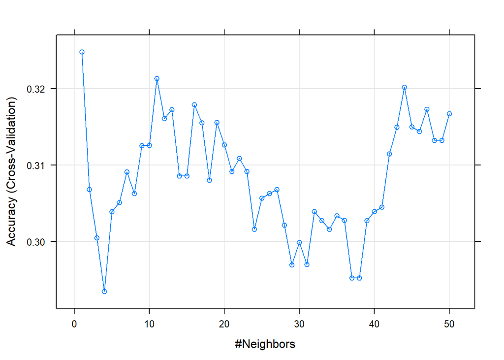

```r
ctrl1=trainControl(method="cv",number=10)
grid.k=data.frame(k=seq(1,50,by=1))
sel.k=train(score_class~.,data=train.classification,method="knn",trControl=ctrl1,tuneGrid=grid.k)
plot(sel.k)
```

```r
#The best K will be selected with the Accuracy
best.k = which.max(sel.k$results$Accuracy)


print(paste("Best k for k-NN: ", best.k))
```

```
## [1] "Best k for k-NN:  1"
```

**Random forest**

selecting best mtry for a random forest using 10-fold cross validations

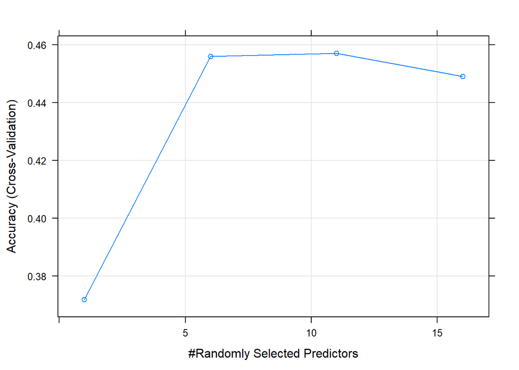

```r
grid.mtry = data.frame(mtry=seq(1, 20, by=5))
sel.mtry = train(score_class~., data=train.classification, trControl=ctrl.cv, tuneGrid=grid.mtry)
plot(sel.mtry)
```

```r
#The best mtry will be selected with the Accuracy
sel.mtry
```

```
## Random Forest
##
## 1724 samples
##   23 predictor
##    4 classes: 'A', 'B', 'D', 'F'
##
## No pre-processing
## Resampling: Cross-Validated (10 fold)
## Summary of sample sizes: 1551, 1552, 1551, 1552, 1552, 1551, ...
## Resampling results across tuning parameters:
##
##   mtry  Accuracy   Kappa
##    1    0.3718242  0.0958039
##    6    0.4559114  0.2577908
##   11    0.4570608  0.2605209
##   16    0.4489548  0.2501719
##
## Accuracy was used to select the optimal model using the largest value.
## The final value used for the model was mtry = 11.
```

```r
best.mtry=6
print(paste("Best mtry for Random Forest: ", best.mtry))
```

```
## [1] "Best mtry for Random Forest:  6"
```

The most relevent variable is the duration

```r
varImp(sel.mtry)
```

```
## rf variable importance
##
##   only 20 most important variables shown (out of 23)
##
##                        Overall
## duration               100.000
## actor_3_facebook_likes  95.435
## actor_2_facebook_likes  87.057
## actor_1_facebook_likes  82.232
## facenumber_in_poster    39.798
## Drama                   14.064
## Action                  11.767
## Comedy                  11.174
## `content_rating_PG-13`  10.752
## Romance                 10.538
## Thriller                10.450
## content_rating_R         8.999
## Fantasy                  8.479
## Sci_fi                   8.347
## Adventure                8.146
## Crime                    8.054
## Horror                   7.872
## country_USA              6.748
## content_rating_PG        5.913
## country_UK               3.080
```

The most significant variable is the duration. It is quite surprising because you rarely think about the duration of the movie to determine its sucess/quality.

The cast facebook likes being the second most important variables is more relevant since it gives us an idea about the notoriety of the movie

```r
levels(val.classification$score_class) = c(1,2,3,4)
colnames(val.classification)=make.names(colnames(val.classification))
result = foreach(fold=iter(folds), .packages=c("tidyverse", "class", "rpart", "rpart.plot", "ranger", "pROC"), .combine=rbind) %dopar% {

  val.train = val.classification %>% slice(-fold)
  val.test = val.classification %>% slice(fold)

  eval.df = data.frame(yhat.knn=NA, yhat.rf=NA,
                     yobs=val.test$score_class)

  #Predicting using KNN with the selected K
  eval.df$yhat.knn = knn(val.train, val.test, val.train$score_class, k=best.k)

  #Predicting using Random Forest with the selected mtry
  rf = ranger(score_class~.,data=val.train,mtry=best.mtry)
  eval.df$yhat.rf = predict(rf, data=val.test)[1]$predictions

  eval.df %>% summarise_all(funs(mean((yobs!=.)))) %>%
    select(contains("yhat")) %>%
    gather(id, value) %>%
    separate(id, c("model", "metric"), sep="_") %>%
    spread(key=metric, value=value)

}

result %>% group_by(model) %>%
 summarise_all(mean)
```

```
## # A tibble: 2 x 2
##   model    `<NA>`
##   <chr>     <dbl>
## 1 yhat.knn  0.690
## 2 yhat.rf   0.571
```

Classification conclusion:

- The best algorithm for classifying the data is the random forest

BUT still the accuracy is just of 43%.

# VI) Conclusion

Despite our efforts on processing our dataset, we noticed that it is really challenging to determine and perform a regression analysis on it. The different results on both classification and regression are not excellent.

This shows that the information provided in the dataset isn’t enough to properly classify a movie nor predict its score or gross. The information we get from the results is quite poor, as the most significant variable to classify a movie is by its duration.